# Chapter 5

# Measures of Dispersion

## What is Dispersion as a Concept?

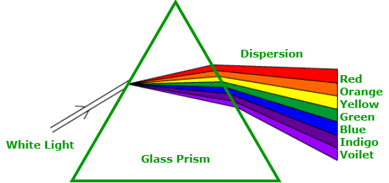

image:geeksforgeeks

## What is Dispersion within Statistics?

It is the amount of spread or variability among raw scores in a distribution.

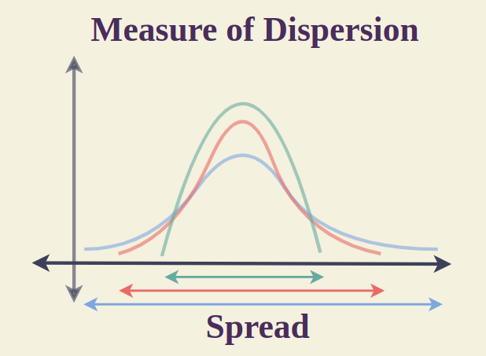

image:geeksforgeeks

## Kurtosis - the Cousin of Skewness

The ‘sharpness’ of the peak of a frequency-distribution curve.

The ‘sharpness’ of the peak occurs due to the tailedness (i.e., how often outliers occur) with the distribution.

[figure not shown]

## Types of Kurtosis

Leptokurtosis

Mesokurtosis

#### data closely resembles that of a normal distribution

Platykurtosis

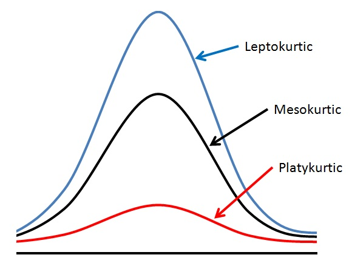

image:Bogleheads

## Measures of Dispersion for Categorical Variables

The Variation Ratio

- A measure of dispersion.
- The proportion of cases which are not in the mode category.
- The only measure of dispersion that can be used with categorical variables

## The Variation Ratio

$$v = 1 - \frac{fm}{n}$$

$fm$ = the frequency (number of cases) of the mode

$n$ = sample size

## Varition Ratio Example

We asked 1,984 individuals at the University what their favorite color was. We were left with four colors: red, orange, green, and blue. What is the variation score?

```
       colors
Red        43
Orange    211
Green     341
Blue     1389
```

$$v = 1 - \frac{fm}{n}$$

## Recap

Dispersion

Kurtosis

- Leptokurtosis
- Mesokurtosis
- Platykurtosis

The Variation Ratio

## Measures of Dispersion for Continious Variables

Range

Variance

Standard Deviation

## Range

A measure of the span of data.

A high range value indicates there is more dispersion, and the lower the range, the less the dispersion

$$Range = The \, Maximum \, Value - The \, Minimum \, Value$$

## Range Example

Below is a data frame that contains the average salary within each district. Find the range.

```
          Salary
District1  87000
District2  91000
District3  66500
District4  98500
District5  96500
District6  97550
District7  97900
District8  97990
```

$$?$$

## Variance

A measure of how spread the observed values are from the mean.

$$s^2 = \frac{\sum(x_i - \bar{x})^2}{n-1}$$

$s^2$ = sample variance  
$x_i$ = raw value  
$\bar{x}$ = mean values of all raw scores  
$n$ = number of observations

## Break Down of Equation

1. Find the $\bar{x}$
2. Subtract the mean from each score $(x_i - \bar{x})$
3. Square the deviation score $(x_i - \bar{x})^2$
4. Add the squared deviations ${\sum(x_i - \bar{x})^2}$
5. Divide by ${n-1}$

$$s^2 = \frac{\sum(x_i - \bar{x})^2}{n-1}$$

## Why n-1?

Suppose we draw n independent observations from a population (N), with a unknown population mean $(\mu)$ and unknown variance $(s^2)$.

Ideally we would use $(s^2)$ to find the average squared distance from the true mean,

$$s^2 = \frac{\sum(x_i - \mu)^2}{n}$$

Although we can’t! 😢

Because we don’t know our $(\mu)$.

## We Sample it!

Since we don’t know $(\mu)$, we use our best estimate of it which is the sample mean $\bar{x}$.

So let’s pull out the population variable $(\mu)$ and plug in our [sample variables ($\bar{x}$).

$$s^2 = \frac{\sum(x_i - \bar{x})^2}{n}$$

Although another small problems pops up!

## The Problem (Population)

Population and the true ${\mu}$

$$(-5,0)*--*-*-*----(0,0)--\stackrel{\mu}{|}--*--*--*--- (5,0)$$

## The Problem (Sample)

Sample and the $\bar{x}$

$$(-5,0)*--*-*-----(0,0)--\stackrel{\mu}{|}--------- (5,0)$$

The sample mean can tend to underestimate or even overestimate the true ${\mu}$

## The Solution

We modify $s^2 = \frac{\sum(x_i - \bar{x})^2}{n}$ to $s^2 = \frac{\sum(x_i - \bar{x})^2}{n-1}$

And this provides an unbiased estimator of the population variance when using a sample.

[figure not shown]

image: khan academy

## In Sum

When we are measuring a population, divide by n. (hint: There will be a $\mu$ in the deviation score.)

When we are measuring a sample, divide by n-1. (hint: There will be a $\bar{x}$ in the deviation score.)

## Variance Example 1

#### 1) Find the $\bar{x}$

#### 2) Subtract the mean from each score $(x_i - \bar{x})$

#### 3) Square the deviation score $(x_i - \bar{x})^2$

#### 4) Add the squared deviations ${\sum(x_i - \bar{x})^2}$

#### 5) Divide by ${n-1}$

```
   District Salary
1 District1    832
2 District2    931
3 District3   1468
4 District4   1021
5 District5   1039
6 District6   1515
7 District7   1138
8 District8    620
```

$$s^2 = \frac{\sum(x_i - \bar{x})^2}{n-1}$$

## Variance Example 2

#### 1) Find the $\bar{x}$

#### 2) Subtract the mean from each score $(x_i - \bar{x})$

#### 3) Square the deviation score $(x_i - \bar{x})^2$

#### 4) Add the squared deviations ${\sum(x_i - \bar{x})^2}$

#### 5) Divide by ${n-1}$

```
   District Salary
1 District1    983
2 District2    993
3 District3   1047
4 District4   1002
5 District5   1004
6 District6   1051
7 District7   1014
8 District8    962
```

$$s^2 = \frac{\sum(x_i - \bar{x})^2}{n-1}$$

## Standard Deviation

A measure of how far observed values are from the mean.

It’s simply the square root of our variance!

$$\sigma=\sqrt{\frac{\sum_{} (x_{i} - \bar{x})^2}{n-1}}$$
$\sigma$ = standard deviation
$x_i$ = raw value
$\bar{x}$ = mean values of all raw scores
$n$ = number of observations

## Why square root it?

In our variance equation, we squared the sum of the deviation score $(x_i - \bar{x})$ to get rid of our negative values.

$$s^2 = \frac{\sum(x_i - \bar{x})^2}{n-1}$$
But by doing that we created an output that is nonsensical to our data and thus our interpretation.

$$\sigma=\sqrt{\frac{\sum_{} (x_{i} - \bar{x})^2}{n-1}}$$

## Standard Deviation Example

```
   District Salary
1 District1    832
2 District2    931
3 District3   1468
4 District4   1021
5 District5   1039
6 District6   1515
7 District7   1138
8 District8    620
```

$$\sigma=\sqrt{\frac{\sum_{} (x_{i} - \bar{x})^2}{n-1}}$$

## Vizualize a Standard Deviation

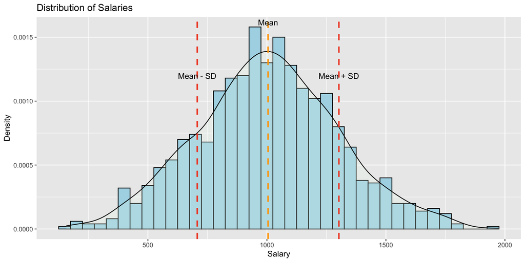

## Vizualize a Standard Deviation (Large)

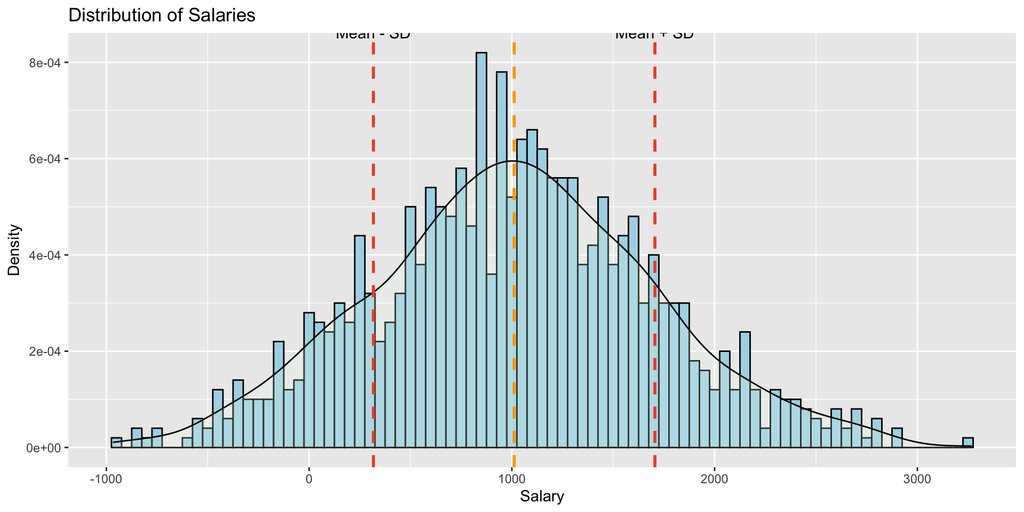

## Vizualize a Standard Deviation (Small)

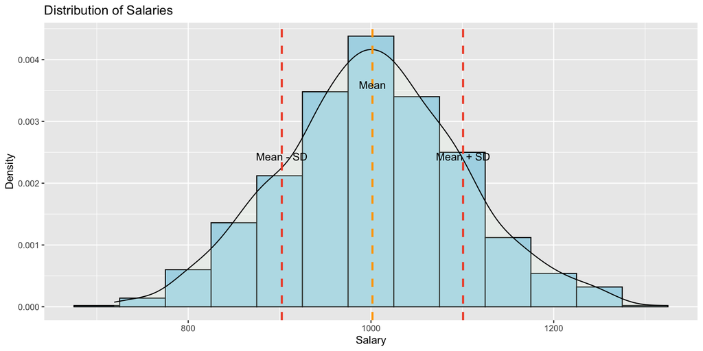

## The Normal Curve

On average, 68% of the sample will fall within 1 standard deviation of the mean, 95% at 2 standard deviations, and 99.7% will fall within 3 standard deviations.

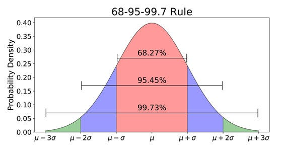

image: medium

## Have Wonderful Day!

[figure not shown]

Giphy